# Estudios de Informática, Multimedia y Telecomunicaciones

# Practica 2 - Tipologia y ciclo de vida de los datos

Autores: Luis Castro y Marc Valdivia Arriaza

Diciembre 2019

[figure not shown]

Titanic

# 1 Descripción del dataset.

¿Por qué es importante y qué pregunta/problema pretende responder?

Hemos elegido como dataset para esta practica el dataset de dsatos de supervivientes del titanic, el dtaset esta disponible en la pagina https://www.kaggle.com/c/titanic/data, actualemnte esta dispnoible como parte de un concurso de machine learning.

Los datos estan en 2 archivos:

- conjunto de entrenamiento (train.csv)
- conjunto de prueba (test.csv)

El conjunto de entrenamientotiene la intencion de ser usado para la creacion de los modelos de aprendizaje. en el caso del conjunto de entrenamiento se proporcionamos el resultado para cada pasajero. contienen informacion de los pasajeros y su intencion es tratar de adivinar el resultado de cada pasajero en ese fatidico incidente.

El conjunto de pruebaesta para probar y ver qué tan bien funciona su modelo con datos no vistos.

el data set cuenta con los siguientes campos:

- survival: (supervivencia) 0 = No, 1 = Yes
- pclass Ticket class: (clase del pasajero) 1 = 1st, 2 = 2nd, 3 = 3rd
- sex (genero)
- Age (edad)
- sibsp (# heramanos o esposo/a)
- parch (# padres hijos )
- ticket (Ticket number)id tiquete)
- fare Passenger fare (costo del pasaje)
- cabin (# cabina)
- embarked Port of Embarkation (puerto de embarque) C = Cherbourg, Q = Queenstown, S = Southampton

Este date set busca entender a partir de los distintos campos que se cuentan, las probabilidades de sobrevivir de acuerdo a las condiciones de cada pasajero. por ejemplo se cumplio el dicho de mujeres y niños primero? tuvieron alguna ventaja los pasajeros de las clases mas altas? cual fue la situacion con las familias? tenia mas psoibilidad e sobrevivir quien viajaba solo?

# 2 Integración y selección de los datos de interés a analizar

Procedemos a cargar los datos:

```r
ds<-read.csv("train.csv", header=T, sep=",", na.strings=c("","na"))
```

verifiquemos las columnas cargadas

```r
colnames(ds)
```

```
##  [1] "PassengerId" "Survived"    "Pclass"      "Name"        "Sex"
##  [6] "Age"         "SibSp"       "Parch"       "Ticket"      "Fare"
## [11] "Cabin"       "Embarked"
```

numero de filas

```r
n <-nrow(ds)
n
```

```
## [1] 891
```

# 3 Limpieza de los datos.

## 3.1 ¿Los datos contienen ceros o elementos vacíos? ¿Cómo gestionarías cada uno de estos casos?

buscamos valores NA

```r
colSums(is.na(ds))
```

```
## PassengerId    Survived      Pclass        Name         Sex         Age
##           0           0           0           0           0         177
##       SibSp       Parch      Ticket        Fare       Cabin    Embarked
##           0           0           0           0         687           2
```

podemos ver que contamos con 177 NA o campos vacios en la variablea Age para la edad de los pasajeros

se pueden tomar 2 caminos podriamos eliminar estos registros o podriaos asignar un valor a estos NA

para este caso no podriamos eliminarlos pues son muchos (177) y esto podria afectar la precision de nuestro analisis.

podriamos asignar el valor de la media a estos campos faltantes, pero si analizamos hombres y mujeres cuentan con distintas expectativas de vida, asi que calcularemos la media de los hombres y la media de las mujeres y lo asignaremos respectivamente.

```r
mujeres <-subset(ds, Sex == "female")
str(mujeres)
```

```
## 'data.frame':    314 obs. of  12 variables:
##  $ PassengerId: int  2 3 4 9 10 11 12 15 16 19 ...
##  $ Survived   : int  1 1 1 1 1 1 1 0 1 0 ...
##  $ Pclass     : int  1 3 1 3 2 3 1 3 2 3 ...
##  $ Name       : Factor w/ 891 levels "Abbing, Mr. Anthony",..: 191 358 277 417 581 732 96 847 364 846 ...
##  $ Sex        : Factor w/ 2 levels "female","male": 1 1 1 1 1 1 1 1 1 1 ...
##  $ Age        : num  38 26 35 27 14 4 58 14 55 31 ...
##  $ SibSp      : int  1 0 1 0 1 1 0 0 0 1 ...
##  $ Parch      : int  0 0 0 2 0 1 0 0 0 0 ...
##  $ Ticket     : Factor w/ 681 levels "110152","110413",..: 597 670 50 345 133 617 39 414 154 302 ...
##  $ Fare       : num  71.28 7.92 53.1 11.13 30.07 ...
##  $ Cabin      : Factor w/ 147 levels "A10","A14","A16",..: 82 NA 56 NA NA 146 50 NA NA NA ...
##  $ Embarked   : Factor w/ 3 levels "C","Q","S": 1 3 3 3 1 3 3 3 3 3 ...
```

```r
hombres <-subset(ds, Sex == "male")

meanmujeres <- mean(mujeres$Age, na.rm= TRUE)

meanhombres <- mean(hombres$Age, na.rm= TRUE)
meanhombres
```

```
## [1] 30.72664
```

```r
meanmujeres
```

```
## [1] 27.91571
```

como sospechabamos la media de hombres y mujeres es diferente

asignamo las respectivas medias a los valores NA de Age

```r
ds$Age[is.na(ds$Age) & ds$Sex=="male" ] <- meanhombres
ds$Age[is.na(ds$Age) & ds$Sex=="female" ] <- meanmujeres
```

buscamos valores NA de nuevo

```r
colSums(is.na(ds))
```

```
## PassengerId    Survived      Pclass        Name         Sex         Age
##           0           0           0           0           0           0
##       SibSp       Parch      Ticket        Fare       Cabin    Embarked
##           0           0           0           0         687           2
```

ya no contamos con datos faltantes en edad, procedemos a solucionar el problema con embarked:

en este caso contamos con solo 2 registros

podemos tomar 2 caninos

- podriamos eliminar los 2 registros pues son pocos
- podriamos asignarlos a la categoria que cuenta con mas poblacion

revisamos:

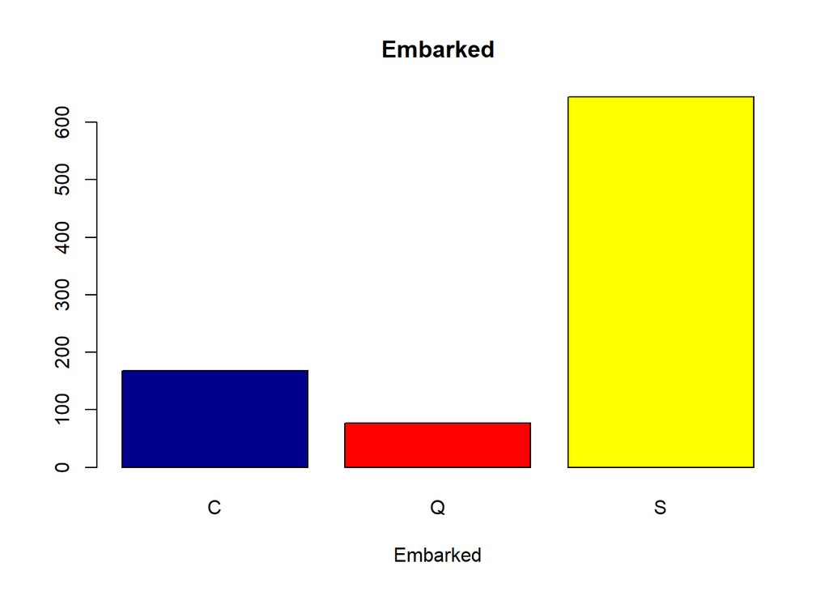

```r
 counts <- table(ds$Embarked)
 barplot(counts, main="Embarked", col=c("darkblue","red", "yellow"),
   xlab="Embarked")
```

observamos que S (Southampton) tiene la gran mayoria, los agregaremos a esta categoria

```r
ds$Embarked[is.na(ds$Embarked) ] <- "S"
```

confirmamos que ya no tenemos datos faltantes en embarked

```r
colSums(is.na(ds))
```

```
## PassengerId    Survived      Pclass        Name         Sex         Age
##           0           0           0           0           0           0
##       SibSp       Parch      Ticket        Fare       Cabin    Embarked
##           0           0           0           0         687           0
```

por ultimo tenemos Cabin

en este caso tenemos una cantidad muy grande datos faltantes

```r
sum(is.na(ds$Cabin)) /n
```

```
## [1] 0.7710438
```

tenemos el 77 % de pasajeros sin datos de cabina

es un porcentaje muy alto, por lo tanto no vale la pena realmente eliminarlos pues quedariamos con muy pocos datos tampoco podemos buscar la forma de reemplazarlos, no tiene valor analitico decir que todos los pasajeros iban unos pocos cuartos.

por lo tanto en este caso no tomaremos en cuenta los datos de cabinas para nuestro analisis

removemos los datos de cabina

```r
ds <- subset( ds, select = -Cabin )

colSums(is.na(ds))
```

```
## PassengerId    Survived      Pclass        Name         Sex         Age
##           0           0           0           0           0           0
##       SibSp       Parch      Ticket        Fare    Embarked
##           0           0           0           0           0
```

Fare:

a pesar de que ya pareciera que no tenemos Nas si observamos la columna Fare (costo del tiquete) vemos algunos registros con 0

estos obviamente son valores perdidos pues nadie viaja gratis

en este caso tampoco nos sirve eliminar los registros pq son bastantes, tampoco podemos usar la media para asignar.

suponemos que el puerto de embarque es un factor que afecta la tarifa, pues entre mas largo podria ser mas caro

tambien la clase del pasajero influye, no es lo mismo el precio de primera clase versus segunda clase.

entonces segmentaremos por grupos y calcularemos la media para cada grupo tomando en cuenta la clase del pasajero asi como su puerto de embarque

utilizamos la funcion summary by de libreria doBy

```r
library(doBy)
medias <- summaryBy(Fare ~ Embarked + Pclass, data =ds, FUN = median)
medias
```

```
##   Embarked Pclass Fare.median
## 1        C      1     78.2667
## 2        C      2     24.0000
## 3        C      3      7.8958
## 4        Q      1     90.0000
## 5        Q      2     12.3500
## 6        Q      3      7.7500
## 7        S      1     52.5542
## 8        S      2     13.5000
## 9        S      3      8.0500
```

asignamos los valores respectivamentes:

```r
ds$Fare[ds$Embarked =='C' & ds$Pclass == '1' & ds$Fare ==0] <- medias$Fare.median[1]
ds$Fare[ds$Embarked =='C' & ds$Pclass == '2' & ds$Fare ==0] <- medias$Fare.median[2]
ds$Fare[ds$Embarked =='C' & ds$Pclass == '3' & ds$Fare ==0] <- medias$Fare.median[3]
ds$Fare[ds$Embarked =='Q' & ds$Pclass == '1' & ds$Fare ==0] <- medias$Fare.median[4]
ds$Fare[ds$Embarked =='Q' & ds$Pclass == '2' & ds$Fare ==0] <- medias$Fare.median[5]
ds$Fare[ds$Embarked =='Q' & ds$Pclass == '3' & ds$Fare ==0] <- medias$Fare.median[6]
ds$Fare[ds$Embarked =='S' & ds$Pclass == '1' & ds$Fare ==0] <- medias$Fare.median[7]
ds$Fare[ds$Embarked =='S' & ds$Pclass == '2' & ds$Fare ==0] <- medias$Fare.median[8]
ds$Fare[ds$Embarked =='S' & ds$Pclass == '3' & ds$Fare ==0] <- medias$Fare.median[9]
```

ya contamos con todos nuestros datos completos

ahora revisemos tipos de datos:

```r
str(ds)
```

```
## 'data.frame':    891 obs. of  11 variables:
##  $ PassengerId: int  1 2 3 4 5 6 7 8 9 10 ...
##  $ Survived   : int  0 1 1 1 0 0 0 0 1 1 ...
##  $ Pclass     : int  3 1 3 1 3 3 1 3 3 2 ...
##  $ Name       : Factor w/ 891 levels "Abbing, Mr. Anthony",..: 109 191 358 277 16 559 520 629 417 581 ...
##  $ Sex        : Factor w/ 2 levels "female","male": 2 1 1 1 2 2 2 2 1 1 ...
##  $ Age        : num  22 38 26 35 35 ...
##  $ SibSp      : int  1 1 0 1 0 0 0 3 0 1 ...
##  $ Parch      : int  0 0 0 0 0 0 0 1 2 0 ...
##  $ Ticket     : Factor w/ 681 levels "110152","110413",..: 524 597 670 50 473 276 86 396 345 133 ...
##  $ Fare       : num  7.25 71.28 7.92 53.1 8.05 ...
##  $ Embarked   : Factor w/ 3 levels "C","Q","S": 3 1 3 3 3 2 3 3 3 1 ...
```

survived y PCclass deberian ser factores

```r
ds$Pclass<- factor(ds$Pclass, labels =c("Primera", "Segunda", "Tercera"))
ds$Survivedfactor<- factor(ds$Survived, labels =c("No", "Si"))
```

creamos un campo facotr para la edad para difernciar ninos de adultos

```r
ds$AgeF[ds$Age < 16]<- "nino"
ds$AgeF[ds$Age >= 16]<- "adulto"
ds$AgeF <- as.factor(ds$AgeF)
```

```r
str(ds)
```

```
## 'data.frame':    891 obs. of  13 variables:
##  $ PassengerId   : int  1 2 3 4 5 6 7 8 9 10 ...
##  $ Survived      : int  0 1 1 1 0 0 0 0 1 1 ...
##  $ Pclass        : Factor w/ 3 levels "Primera","Segunda",..: 3 1 3 1 3 3 1 3 3 2 ...
##  $ Name          : Factor w/ 891 levels "Abbing, Mr. Anthony",..: 109 191 358 277 16 559 520 629 417 581 ...
##  $ Sex           : Factor w/ 2 levels "female","male": 2 1 1 1 2 2 2 2 1 1 ...
##  $ Age           : num  22 38 26 35 35 ...
##  $ SibSp         : int  1 1 0 1 0 0 0 3 0 1 ...
##  $ Parch         : int  0 0 0 0 0 0 0 1 2 0 ...
##  $ Ticket        : Factor w/ 681 levels "110152","110413",..: 524 597 670 50 473 276 86 396 345 133 ...
##  $ Fare          : num  7.25 71.28 7.92 53.1 8.05 ...
##  $ Embarked      : Factor w/ 3 levels "C","Q","S": 3 1 3 3 3 2 3 3 3 1 ...
##  $ Survivedfactor: Factor w/ 2 levels "No","Si": 1 2 2 2 1 1 1 1 2 2 ...
##  $ AgeF          : Factor w/ 2 levels "adulto","nino": 1 1 1 1 1 1 1 2 1 2 ...
```

## 3.2 Identificación y tratamiento de valores extremos

para el tratamientode valores extremos usaremos las siguiente funcion toamda de https://datascienceplus.com/identify-describe-plot-and-removing-the-outliers-from-the-dataset/

que funciona identificando, describendo los valores extremos. usa el comando boxplot.stats () $ out, que utiliza el método de Tukey para identificar los valores atípicos que se encuentran por encima y por debajo del 1.5 * IQR.

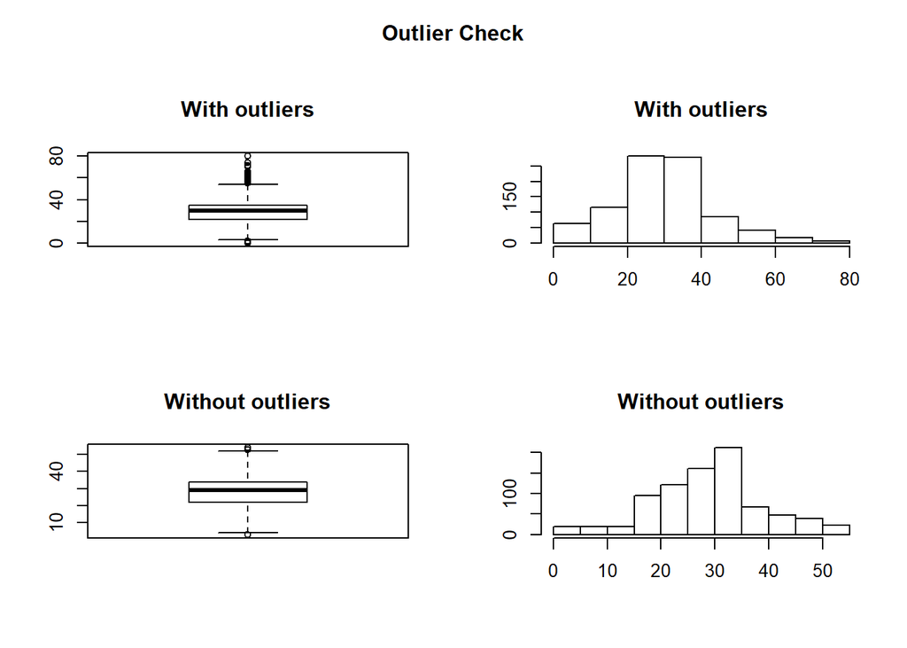

```
## Outliers identified: 66 nPropotion (%) of outliers: 8 nMean of the outliers: 39.94 nMean without removing outliers: 29.74 nMean if we remove outliers: 28.92 nDo you want to remove outliers and to replace with NA? [yes/no]:
## Nothing changed n
```

```r
outlierKD <- function(dt, var) {
     var_name <- eval(substitute(var),eval(dt))
     na1 <- sum(is.na(var_name))
     m1 <- mean(var_name, na.rm = T)
     par(mfrow=c(2, 2), oma=c(0,0,3,0))
     boxplot(var_name, main="With outliers")
     hist(var_name, main="With outliers", xlab=NA, ylab=NA)
     outlier <- boxplot.stats(var_name)$out
     mo <- mean(outlier)
     var_name <- ifelse(var_name %in% outlier, NA, var_name)
     boxplot(var_name, main="Without outliers")
     hist(var_name, main="Without outliers", xlab=NA, ylab=NA)
     title("Outlier Check", outer=TRUE)
     na2 <- sum(is.na(var_name))
     cat("Outliers identified:", na2 - na1, "n")
     cat("Propotion (%) of outliers:", round((na2 - na1) / sum(!is.na(var_name))*100, 1), "n")
     cat("Mean of the outliers:", round(mo, 2), "n")
     m2 <- mean(var_name, na.rm = T)
     cat("Mean without removing outliers:", round(m1, 2), "n")
     cat("Mean if we remove outliers:", round(m2, 2), "n")
     response <- readline(prompt="Do you want to remove outliers and to replace with NA? [yes/no]: ")
     if(response == "y" | response == "yes"){
          dt[as.character(substitute(var))] <- invisible(var_name)
          assign(as.character(as.list(match.call())$dt), dt, envir = .GlobalEnv)
          cat("Outliers successfully removed", "n")
          return(invisible(dt))
     } else{
          cat("Nothing changed", "n")
          return(invisible(var_name))
     }
}
outlierKD(ds,Age)
```

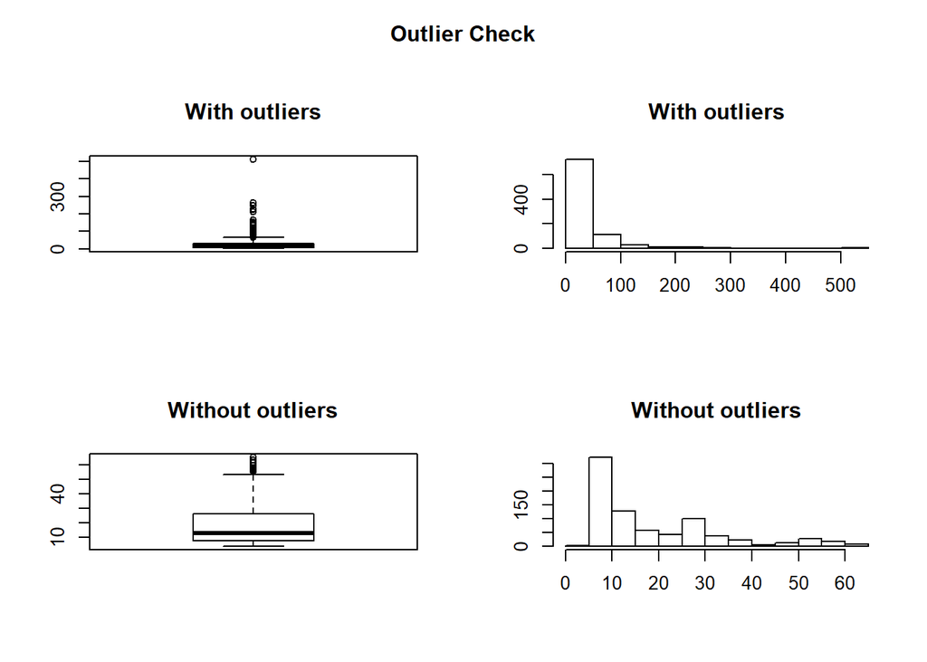

```
## Outliers identified: 116 nPropotion (%) of outliers: 15 nMean of the outliers: 128.29 nMean without removing outliers: 32.63 nMean if we remove outliers: 18.31 nDo you want to remove outliers and to replace with NA? [yes/no]:
## Nothing changed n
```

```r
outlierKD(ds,Fare)
```

analizamos las variables edad y la tarifa

ambas nos muestran un numero importante de valores extremos

como tratamiento no lo eliminaremos pues creemos que nos pueden agregar valor al analisis, por ejemplo si eliminamos los valores extremos de edad eliminariamos registros de gran cantidad de adultos mayores

# 4 Análisis de los datos

## 4.1 Selección de los grupos a analizar

En primer lugar, seleccionaremos varios grupos de pasarejos en función de varias características para poder realizar un análisis estadístico.

```r
ds.priemra <- ds[ds$Pclass == "Primera", ]
ds.segunda <- ds[ds$Pclass == "Segunda", ]
ds.tercera <- ds[ds$Pclass == "Tercera", ]


ds.hombres <- ds[ds$Sex == "male", ]
ds.mujeres <- ds[ds$Sex == "female", ]

ds.ninos <- ds[ds$Age < 16, ]
ds.adultos <- ds[ds$Age >= 16, ]
```

## 4.2 Comprobación de la normalidad y homogeneidad de la varianza

```r
#install.packages("nortest")
library(nortest)

alpha = 0.05
col.names = colnames(ds)
for (i in 1:ncol(ds)) {
  if (i == 1) cat("Variables que no siguen una distribución normal:\n")
  if (is.integer(ds[,i]) | is.numeric(ds[,i])) {
    p_val = ad.test(ds[,i])$p.value
    if (p_val < alpha) {
      cat(col.names[i])
      # Format output
      if (i < ncol(ds) - 1) cat(", ")
      if (i %% 3 == 0) cat("\n")
    }
  }
}
```

```
## Variables que no siguen una distribución normal:
## PassengerId, Survived, Age,
## SibSp, Parch, Fare,
```

De las variables que no siguen una distribución normal, podemos ignorar `PassengerId`, ya que hace referencia al identificador único del pasajero y no debe seguir ninguna distribución.

A continuación estudiaremos la homegeneidad de varianzas con el test de Fliger-Killeen según el sexo y el tipo de clase donde se encontraban.

```r
fligner.test(Survived ~ Sex, data = ds)
```

```
##
##  Fligner-Killeen test of homogeneity of variances
##
## data:  Survived by Sex
## Fligner-Killeen:med chi-squared = 5.7729, df = 1, p-value = 0.01627
```

```r
fligner.test(Survived ~ Pclass, data = ds)
```

```
##
##  Fligner-Killeen test of homogeneity of variances
##
## data:  Survived by Pclass
## Fligner-Killeen:med chi-squared = 35.766, df = 2, p-value = 1.712e-08
```

En ambos casos hemos obtenido un valor inferior a 0,05, por lo que tenemos que rechazar la hipótesis de que las varianzas son homogéneas en ninguno de los casos.

## 4.3 Pruebas estadísticas

### 4.3.1 correlaciones

```r
corr_matrix <- matrix(nc = 2, nr = 0)
colnames(corr_matrix) <- c("estimate", "p-value")
# Calcular el coeficiente de correlación para cada variable cuantitativa
# con respecto al campo "precio"
for (i in 1:(ncol(ds) - 1)) {
  if (is.integer(ds[,i]) | is.numeric(ds[,i])) {
    spearman_test = cor.test(ds[,i], ds$Survived, method = "pearson")
    corr_coef = spearman_test$estimate
    p_val = spearman_test$p.value
    # Add row to matrix
    pair = matrix(ncol = 2, nrow = 1)
    pair[1][1] = corr_coef
    pair[2][1] = p_val
    corr_matrix <- rbind(corr_matrix, pair)
    rownames(corr_matrix)[nrow(corr_matrix)] <- colnames(ds)[i]
  }
}
```

```r
print(corr_matrix)
```

```
##                 estimate      p-value
## PassengerId -0.005006661 8.813658e-01
## Survived     1.000000000 0.000000e+00
## Age         -0.080453450 1.630444e-02
## SibSp       -0.035322499 2.922439e-01
## Parch        0.081629407 1.479925e-02
## Fare         0.251502447 2.546254e-14
```

La matriz de correlación nos indica cuáles son las variables que más relación tienen con la salida de supervivencia. El atributo `Fare` es el que tiene un valor absoluto más cercano a 1, el siguiente sería `Parch` seguido de `Age` pero con una relación bastante más débil.

A continuación realizaremos varios test de hipótesis para detectar como influyen los atributos categóricos entre ellos.

```r
ds.primera.survived <- ds[ds$Pclass == "Primera", ]$Survived
ds.segunda.survived <- ds[ds$Pclass == "Segunda", ]$Survived
ds.tercera.survived <- ds[ds$Pclass == "Tercera", ]$Survived


ds.hombres.survived <- ds[ds$Sex == "male", ]$Survived
ds.mujeres.survived <- ds[ds$Sex == "female", ]$Survived

ds.ninos.survived <- ds[ds$Age < 16, ]$Survived
ds.adultos.survived <- ds[ds$Age >= 16, ]$Survived
```

### 4.3.2 Pasajeros de Primera vs resto

```r
t.test(rbind(ds.segunda.survived, ds.tercera.survived), ds.primera.survived, alternative = "less")
```

```
##
##  Welch Two Sample t-test
##
## data:  rbind(ds.segunda.survived, ds.tercera.survived) and ds.primera.survived
## t = -7.38, df = 315.15, p-value = 7.084e-13
## alternative hypothesis: true difference in means is less than 0
## 95 percent confidence interval:
##        -Inf -0.2081875
## sample estimates:
## mean of x mean of y
## 0.3615071 0.6296296
```

Al obtener un valor de p-value tan bajo podemos indicar que los pasajeros de primera tenáin más probabilidad de salvarse.

### 4.3.3 Pasajeros de Segunda vs resto

```r
t.test(rbind(ds.primera.survived, ds.tercera.survived), ds.segunda.survived, alternative = "less")
```

```
##
##  Welch Two Sample t-test
##
## data:  rbind(ds.primera.survived, ds.tercera.survived) and ds.segunda.survived
## t = -1.1241, df = 254.59, p-value = 0.131
## alternative hypothesis: true difference in means is less than 0
## 95 percent confidence interval:
##        -Inf 0.02114583
## sample estimates:
## mean of x mean of y
## 0.4276986 0.4728261
```

Los pasajeros de segunda obtienen un valor muy elevado de p-value, por lo que no podemos indicar que tuviesen más probabilidades de salvarse.

### 4.3.4 Pasajeros de Tercera vs resto

```r
t.test(rbind(ds.primera.survived, ds.segunda.survived), ds.tercera.survived, alternative = "less")
```

```
##
##  Welch Two Sample t-test
##
## data:  rbind(ds.primera.survived, ds.segunda.survived) and ds.tercera.survived
## t = 10.018, df = 856.39, p-value = 1
## alternative hypothesis: true difference in means is less than 0
## 95 percent confidence interval:
##       -Inf 0.3592832
## sample estimates:
## mean of x mean of y
## 0.5509259 0.2423625
```

Lo mismo ocurre con los pasajeros de tercera, su probabilidad de salvarese no era mayor.

### 4.3.5 Hombres vs Mujeres

```r
t.test(ds.hombres.survived, ds.mujeres.survived, alternative = "less")
```

```
##
##  Welch Two Sample t-test
##
## data:  ds.hombres.survived and ds.mujeres.survived
## t = -18.672, df = 584.43, p-value < 2.2e-16
## alternative hypothesis: true difference in means is less than 0
## 95 percent confidence interval:
##        -Inf -0.5043259
## sample estimates:
## mean of x mean of y
## 0.1889081 0.7420382
```

El valor del p-value es mucho menor de 0.05. Esto permite afirmar que las mujeres tenían una probabilidad mayor de salvarse y por lo que se cumple el dicho de mujeres primero.

### 4.3.6 Adultos vs Niños

```r
t.test(ds.adultos.survived, ds.ninos.survived, alternative = "less")
```

```
##
##  Welch Two Sample t-test
##
## data:  ds.adultos.survived and ds.ninos.survived
## t = -4.0037, df = 98.605, p-value = 6.046e-05
## alternative hypothesis: true difference in means is less than 0
## 95 percent confidence interval:
##        -Inf -0.1332871
## sample estimates:
## mean of x mean of y
## 0.3626238 0.5903614
```

El valor del p-value es mucho menor de 0.05. Esto permite afirmar que los niños tenían una probabilidad mayor de salvarse y por lo que se cumple el dicho de niños primero.

### 4.3.7 Modelo lineal

En este caso estudiaremos las variables numéricas y su influencia sobre el resultado.

```r
modelo <- lm(Survived ~ Age + SibSp + Parch + Fare, data = ds)
summary(modelo)
```

```
##
## Call:
## lm(formula = Survived ~ Age + SibSp + Parch + Fare, data = ds)
##
## Residuals:
##     Min      1Q  Median      3Q     Max
## -1.0348 -0.3554 -0.2999  0.5525  0.8433
##
## Coefficients:
##              Estimate Std. Error t value Pr(>|t|)
## (Intercept)  0.454825   0.043140  10.543  < 2e-16 ***
## Age         -0.004727   0.001255  -3.765 0.000177 ***
## SibSp       -0.057549   0.015906  -3.618 0.000314 ***
## Parch        0.033109   0.021742   1.523 0.128164
## Fare         0.002668   0.000327   8.156 1.18e-15 ***
## ---
## Signif. codes:  0 '***' 0.001 '**' 0.01 '*' 0.05 '.' 0.1 ' ' 1
##
## Residual standard error: 0.4658 on 886 degrees of freedom
## Multiple R-squared:  0.08762,    Adjusted R-squared:  0.08351
## F-statistic: 21.27 on 4 and 886 DF,  p-value: < 2.2e-16
```

Podemos extraer que la única variable numérica que no parece importante para el modelo lineal es `Parch`, el resto de ellas pareceb tener un código de significancia muy elevado.

### 4.3.8 modelo logistico

```r
 modelo.logit <- glm(Survivedfactor ~ Sex + AgeF + Pclass , data = ds,family = "binomial")
summary(modelo.logit)
```

```
##
## Call:
## glm(formula = Survivedfactor ~ Sex + AgeF + Pclass, family = "binomial",
##     data = ds)
##
## Deviance Residuals:
##     Min       1Q   Median       3Q      Max
## -2.6370  -0.6973  -0.4132   0.6884   2.2374
##
## Coefficients:
##               Estimate Std. Error z value Pr(>|z|)
## (Intercept)     2.2434     0.2194  10.226  < 2e-16 ***
## Sexmale        -2.6095     0.1862 -14.018  < 2e-16 ***
## AgeFnino        1.2022     0.2945   4.082 4.47e-05 ***
## PclassSegunda  -0.9242     0.2467  -3.745  0.00018 ***
## PclassTercera  -2.0515     0.2198  -9.334  < 2e-16 ***
## ---
## Signif. codes:  0 '***' 0.001 '**' 0.01 '*' 0.05 '.' 0.1 ' ' 1
##
## (Dispersion parameter for binomial family taken to be 1)
##
##     Null deviance: 1186.66  on 890  degrees of freedom
## Residual deviance:  809.84  on 886  degrees of freedom
## AIC: 819.84
##
## Number of Fisher Scoring iterations: 4
```

todos los P valores de los regresores son menores 0.05 por lo tanto todos tienen influencia significativa

Interpretación

revisemos

```r
exp(coefficients(modelo.logit))
```

```
##   (Intercept)       Sexmale      AgeFnino PclassSegunda PclassTercera
##    9.42506520    0.07357384    3.32729216    0.39685543    0.12854048
```

realicemos algunas prediciones para cer los rssultados

supongamos una mujer adulta de 1 clase

```r
nuevo= data.frame(Sex="female",AgeF="adulto",Pclass="Primera")
nuevo
```

```
##      Sex   AgeF  Pclass
## 1 female adulto Primera
```

```r
 prediccion <- predict(modelo.logit, nuevo, type = "response" )
prediccion
```

```
##         1
## 0.9040773
```

esta pasajero tendria un 90% de probabilidad de supervivencia

comparemosla con una de mismas caracteristicas pero de tercera clase

```r
nuevo= data.frame(Sex="female",AgeF="adulto",Pclass="Tercera")
nuevo
```

```
##      Sex   AgeF  Pclass
## 1 female adulto Tercera
```

```r
 prediccion <- predict(modelo.logit, nuevo, type = "response" )
prediccion
```

```
##         1
## 0.5478187
```

sus probailidades ade sobrevivir bajan a un 54.7%

todo parece indicar que los ninos tuvieron mas probabilidad de sobrevivir, pero comparemos la probabilidad de sobrevivir de un nino de primera clase versus uno de tercera.

```r
ninoprimera= data.frame(Sex="male",AgeF="nino",Pclass="Primera")
ninotercera= data.frame(Sex="male",AgeF="nino",Pclass="Tercera")
```

```r
prediccionnino1 <- predict(modelo.logit, ninoprimera, type = "response" )
prediccionnino3 <- predict(modelo.logit, ninotercera, type = "response" )
prediccionnino1
```

```
##         1
## 0.6976359
```

```r
prediccionnino3
```

```
##         1
## 0.2287389
```

con esto vemos como un nino de primera clase tenia una probabilidad de sobrevivir del 69.7% versus 22.8 del nino de tercera

se podria decir que se cumplio el mujeres y ninos primero excepto si eres un nino de tercera clase

tratemos de predecir con nuestro modelo logistico la supervivencia para el set de pruebas

primero cargamos el set de pruebas

```r
dstest<-read.csv("test.csv", header=T, sep=",", na.strings=c("","na"))

dstest$Pclass<- factor(dstest$Pclass, labels =c("Primera", "Segunda", "Tercera"))





mujeres <-subset(dstest, Sex == "female")

hombres <-subset(dstest, Sex == "male")

meanmujeres <- mean(mujeres$Age, na.rm= TRUE)

meanhombres <- mean(hombres$Age, na.rm= TRUE)



dstest$Age[is.na(dstest$Age) & dstest$Sex=="male" ] <- meanhombres
dstest$Age[is.na(dstest$Age) & dstest$Sex=="female" ] <- meanmujeres
dstest$AgeF[dstest$Age < 16]<- "nino"
dstest$AgeF[dstest$Age >= 16]<- "adulto"
dstest$AgeF <- as.factor(dstest$AgeF)
```

ahora predecimos los resultados con nuestro modelo logistico

```r
resultados <- predict(modelo.logit,newdata=dstest,type='response')

resultados <- ifelse(resultados > 0.5,"si","no")
dstest$Survived <- resultados
head(dstest,8)
```

```
##   PassengerId  Pclass                                         Name    Sex  Age
## 1         892 Tercera                             Kelly, Mr. James   male 34.5
## 2         893 Tercera             Wilkes, Mrs. James (Ellen Needs) female 47.0
## 3         894 Segunda                    Myles, Mr. Thomas Francis   male 62.0
## 4         895 Tercera                             Wirz, Mr. Albert   male 27.0
## 5         896 Tercera Hirvonen, Mrs. Alexander (Helga E Lindqvist) female 22.0
## 6         897 Tercera                   Svensson, Mr. Johan Cervin   male 14.0
## 7         898 Tercera                         Connolly, Miss. Kate female 30.0
## 8         899 Segunda                 Caldwell, Mr. Albert Francis   male 26.0
##   SibSp Parch  Ticket    Fare Cabin Embarked   AgeF Survived
## 1     0     0  330911  7.8292  <NA>        Q adulto       no
## 2     1     0  363272  7.0000  <NA>        S adulto       si
## 3     0     0  240276  9.6875  <NA>        Q adulto       no
## 4     0     0  315154  8.6625  <NA>        S adulto       no
## 5     1     1 3101298 12.2875  <NA>        S adulto       si
## 6     0     0    7538  9.2250  <NA>        S   nino       no
## 7     0     0  330972  7.6292  <NA>        Q adulto       si
## 8     1     1  248738 29.0000  <NA>        S adulto       no
```

guardamos en un archivo CSV el set de pruebas con las predicciones

```r
write.csv(dstest,'predicciones.csv')
```

# 5 Representación de los resultados a partir de tablas y gráficas.

```r
if(!require(ggplot2)){
    install.packages('ggplot2', repos='http://cran.us.r-project.org')
    library(ggplot2)
}
if(!require(grid)){
    install.packages('grid', repos='http://cran.us.r-project.org')
    library(grid)
}
if(!require(gridExtra)){
    install.packages('gridExtra', repos='http://cran.us.r-project.org')
    library(gridExtra)
}
```

Es nuestra intencion describir la relación existente entre la supervivencia y distintas variables disponibles. vamos a graficar mediante diagramas de barras la cantidad de muertos y supervivientes de acuerdo al sexo,clase, la edad

tambien vamos a representar en tablas los datos que estamos graficando usando el comando table para asi obtener tablas de contingencia.

veamos como se distribuyen los sobrevientes y no sobrevientes de acuerdo a las distintas categorias:

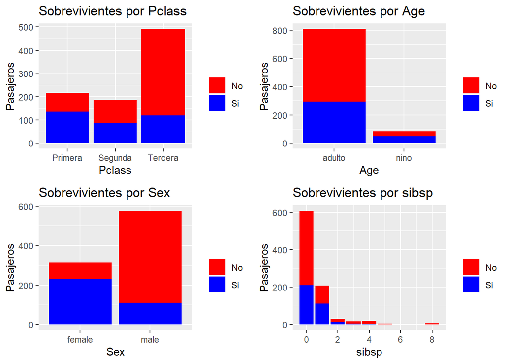

```r
grid.newpage()
plotPclass<-ggplot(ds,aes(Pclass,fill=Survivedfactor))+geom_bar() +labs(x="Pclass", y="Pasajeros")+ guides(fill=guide_legend(title=""))+ scale_fill_manual(values=c("red","blue"))+ggtitle("Sobrevivientes por Pclass")
plotAge<-ggplot(ds,aes(AgeF,fill=Survivedfactor))+geom_bar() +labs(x="Age", y="Pasajeros")+ guides(fill=guide_legend(title=""))+ scale_fill_manual(values=c("red","blue"))+ggtitle("Sobrevivientes por Age")
plotSex<-ggplot(ds,aes(Sex,fill=Survivedfactor))+geom_bar() +labs(x="Sex", y="Pasajeros")+ guides(fill=guide_legend(title=""))+ scale_fill_manual(values=c("red","blue"))+ggtitle("Sobrevivientes por Sex")
plotsibsp<-ggplot(ds,aes(SibSp,fill=Survivedfactor))+geom_bar() +labs(x="sibsp", y="Pasajeros")+ guides(fill=guide_legend(title=""))+ scale_fill_manual(values=c("red","blue"))+ggtitle("Sobrevivientes por sibsp")
grid.arrange(plotPclass,plotAge,plotSex,plotsibsp,ncol=2)
```

podemos ver que en el caso de la distribucion por sexo hay un desequilibrio hacia la cantidad de mujeres sobrevientes con respecto a los hombres, apesar de que viajaban muchos mas hombres

igual pasa con los ninos podemos ver que ellos tambien tuvieron una mas alta proporcion de sobrevivir

visualmente tambien podemos afirmar que se cumplio el lema de mujerrs y ninos primero

```r
tabla_SST <- table(ds$Sex, ds$Survivedfactor)
tabla_SST
```

```
##
##           No  Si
##   female  81 233
##   male   468 109
```

```r
prop.table(tabla_SST, margin = 1)
```

```
##
##                 No        Si
##   female 0.2579618 0.7420382
##   male   0.8110919 0.1889081
```

```r
tabla_SCT <- table(ds$Pclass,ds$Survivedfactor)
tabla_SCT
```

```
##
##            No  Si
##   Primera  80 136
##   Segunda  97  87
##   Tercera 372 119
```

```r
prop.table(tabla_SCT, margin = 1)
```

```
##
##                  No        Si
##   Primera 0.3703704 0.6296296
##   Segunda 0.5271739 0.4728261
##   Tercera 0.7576375 0.2423625
```

```r
tabla_SAT <- table(ds$AgeF,ds$Survivedfactor)
tabla_SAT
```

```
##
##           No  Si
##   adulto 515 293
##   nino    34  49
```

```r
prop.table(tabla_SAT, margin = 1)
```

```
##
##                 No        Si
##   adulto 0.6373762 0.3626238
##   nino   0.4096386 0.5903614
```

```r
tabla_SAT.byPclass <- table(ds$AgeF,ds$Survivedfactor,ds$Pclass)
tabla_SAT.byPclass
```

```
## , ,  = Primera
##
##
##           No  Si
##   adulto  79 131
##   nino     1   5
##
## , ,  = Segunda
##
##
##           No  Si
##   adulto  97  68
##   nino     0  19
##
## , ,  = Tercera
##
##
##           No  Si
##   adulto 339  94
##   nino    33  25
```

```
##  [1] "gridExtra" "grid"      "ggplot2"   "nortest"   "doBy"      "stats"
##  [7] "graphics"  "grDevices" "utils"     "datasets"  "methods"   "base"
```

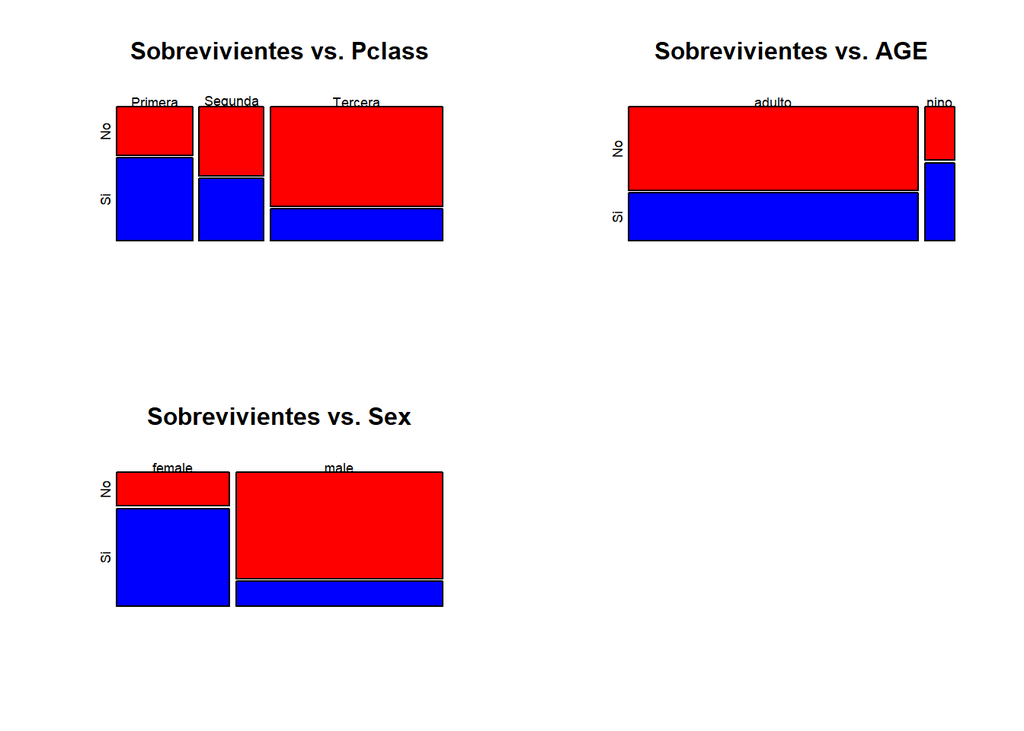

```r
par(mfrow=c(2,2))
plot(tabla_SCT, col = c("red","blue"), main = "Sobrevivientes vs. Pclass")
plot(tabla_SAT, col = c("red","blue"), main = "Sobrevivientes vs. AGE")
plot(tabla_SST, col = c("red","blue"), main = "Sobrevivientes vs. Sex")

(.packages())
```

visualizacion de los datos predecidos por nuestro modelo logistico:

```r
tabla_SST <- table(dstest$Sex, dstest$Survived)
tabla_SST
```

```
##
##           no  si
##   female   0 152
##   male   264   2
```

```r
prop.table(tabla_SST, margin = 1)
```

```
##
##                   no          si
##   female 0.000000000 1.000000000
##   male   0.992481203 0.007518797
```

```r
tabla_SCT <- table(dstest$Pclass,dstest$Survived)
tabla_SCT
```

```
##
##            no  si
##   Primera  55  52
##   Segunda  63  30
##   Tercera 146  72
```

```r
prop.table(tabla_SCT, margin = 1)
```

```
##
##                  no        si
##   Primera 0.5140187 0.4859813
##   Segunda 0.6774194 0.3225806
##   Tercera 0.6697248 0.3302752
```

```r
tabla_SAT <- table(dstest$AgeF,dstest$Survived)
tabla_SAT
```

```
##
##           no  si
##   adulto 247 139
##   nino    17  15
```

```r
prop.table(tabla_SAT, margin = 1)
```

```
##
##                 no        si
##   adulto 0.6398964 0.3601036
##   nino   0.5312500 0.4687500
```

```r
tabla_SAT.byPclass <- table(dstest$AgeF,dstest$Survived,dstest$Pclass)
tabla_SAT.byPclass
```

```
## , ,  = Primera
##
##
##           no  si
##   adulto  55  50
##   nino     0   2
##
## , ,  = Segunda
##
##
##           no  si
##   adulto  60  24
##   nino     3   6
##
## , ,  = Tercera
##
##
##           no  si
##   adulto 132  65
##   nino    14   7
```

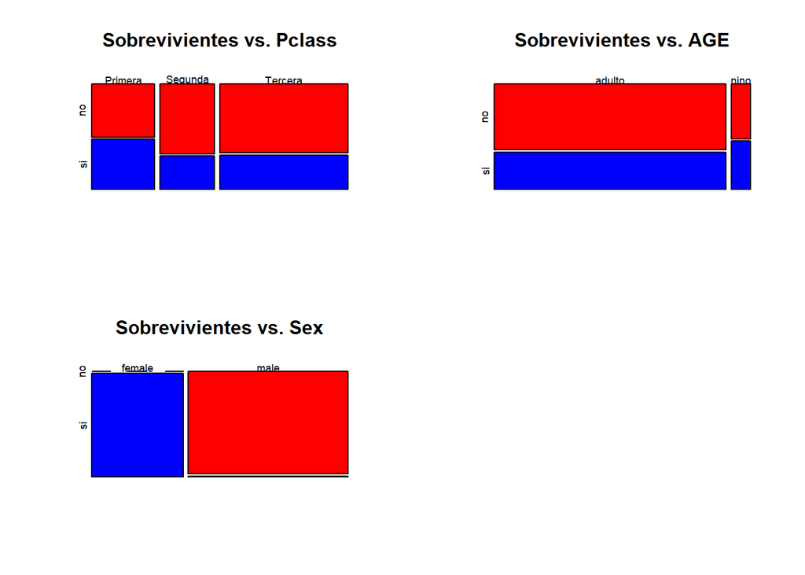

```r
par(mfrow=c(2,2))
plot(tabla_SCT, col = c("red","blue"), main = "Sobrevivientes vs. Pclass")
plot(tabla_SAT, col = c("red","blue"), main = "Sobrevivientes vs. AGE")
plot(tabla_SST, col = c("red","blue"), main = "Sobrevivientes vs. Sex")
```

nuestro modelo logistico se inclina fuertemente por el sexo, matando a la mayoria de los hombres y salvando a todas las mujeres del conjunto de pruebas

# 6 Resolución del problema. A partir de los resultados obtenidos, ¿cuáles son las conclusiones? ¿Los resultados permiten responder al problema?

Los resultados obtenidos del análisis y la visualización de los datos nos han permitido ir respondiendo a las preguntas que se han generado. No solo de forma visual o gráfica, sino también con valores y pruebas estadísticas. Las preguntas más importantes (y que hemos podido resolver) han sido 3. - ¿Había mayor posibilidad de salvarse según el género? Sí, las mueheres tienen una tasa de superviviencia mucho mayor que los hombres, tanto estadísticamente como gráficamente- - ¿Había mayor posibilidad de salvarse para los niños? Sí, también se puede observar claramente en la tabla anterior o en las pruebas estadísticas. - ¿Había mayor posibilidad de salvarse según la clase del billete? Los pasajeros de primera clase tenían una probabilidad mayor de salvarse, los des segunda parece que sí gráficamente pero no podemos estar seguros estadísticamente y los pasajeros de tercera la respuesta es no com ambos métodos. También se ha podido comprobar que los atributos cuantitativos con más influencia sobre el resultado eran la edad `Age` (que relaciona adultos y niños), el `SibSp` (que indica familiaridad) y el `Fare` (que relaciona pasajeros de primera, segunda y tercera).

# 7 Contribuciones

```r
library(knitr)

text_tbl <- data.frame(
  Contribuciones = c( "Investigacion Previa", "Redacción de las respuestas", "Desarrollo código" ),
  Firma = c( "LC, MV","LC, MV","LC, MV"
  )
)

kable(text_tbl)
```

| Contribuciones | Firma |
| --- | --- |
| Investigacion Previa | LC, MV |
| Redacción de las respuestas | LC, MV |
| Desarrollo código | LC, MV |